# Quem faz Iniciação Científica na USP?

- Mostrar o código
- Esconder o código
- Ver o código fonte

Heterogeneidade entre áreas do conhecimento no acesso à Iniciação Científica (2010–2022)

Autores

Afiliações

Tales Mançano

Departamento de Ciência Política, Universidade de São Paulo

Victor Alcantara

Departamento de Sociologia, Universidade de São Paulo

Data de Publicação

30 de agosto de 2026

Resumo

Um estudo anterior mostrou que, na Faculdade de Filosofia, Letras e Ciências Humanas da USP, as características adscritas de origem social explicam pouco o acesso à Iniciação Científica, enquanto a necessidade de trabalhar explica muito. Este artigo pergunta se esse achado descreve a universidade ou apenas uma de suas unidades. Estendemos a mesma especificação às 48 unidades da USP, com 152.729 ingressantes das coortes de 2010 a 2022, classificadas em nove áreas do conhecimento. Encontramos três resultados. Primeiro, a heterogeneidade institucional é enorme e maior do que qualquer efeito individual: a proporção de estudantes que realizam IC vai de 2,7% a 36,1% entre unidades, e saber apenas em que unidade o estudante entrou explica mais da variação individual do que todas as suas características socioeconômicas somadas. Segundo, o mecanismo central do estudo anterior se confirma e se fortalece: na USP inteira, trabalhar em tempo integral reduz mais a probabilidade de fazer IC do que na FFLCH, e continua superando as características de origem em seis das nove áreas. Terceiro, e contra a expectativa, a variável que carrega esse mecanismo muda de área para área — e emerge um fator ausente na FFLCH: em Ciências Agrárias, da Saúde e Engenharias, ser homem reduz a probabilidade de fazer IC entre três e oito pontos percentuais, um efeito que na FFLCH é indistinguível de zero.

Palavras-chave

Iniciação Científica, Educação Superior, Desigualdades Educacionais, Áreas do conhecimento

Este documento é gerado por código: todas as tabelas e figuras são calculadas na compilação, a partir dos microdados. O pacote de replicação está em https://github.com/mancano-tales/Quem-faz-IC-USP, e é irmão do pacote do estudo anterior, https://github.com/mancano-tales/Quem-faz-IC, de quem herda os dados e a especificação do modelo.

# 1 Introdução

Em estudo anterior, analisamos o acesso à Iniciação Científica na Faculdade de Filosofia, Letras e Ciências Humanas da USP e chegamos a uma conclusão que contrariava nossa hipótese inicial: os marcadores tradicionais de origem social — renda familiar e escolaridade dos responsáveis — têm pouco poder explicativo sobre as chances de fazer IC, enquanto o vínculo com o trabalho e a forma de sustento pretendida durante a graduação têm muito. Passado o filtro do vestibular, argumentamos, o mecanismo dominante de reprodução de desigualdades deixa de ser a origem e passa a ser o tempo: quem precisa trabalhar não tem as horas que a IC exige.

Aquele estudo analisou uma unidade. Este pergunta se o achado descreve a universidade.

A pergunta não é retórica. A FFLCH é a maior unidade da USP, mas é atípica em quase tudo o que interessa ao argumento: concentra cursos noturnos, recebe uma proporção de estudantes trabalhadores muito acima da média, e pertence a uma área do conhecimento cuja relação com a pesquisa de graduação é distinta da das ciências experimentais. Se o mecanismo do tempo é geral, deve reaparecer em Engenharias e em Ciências da Saúde. Se não reaparece, o que descrevemos não foi a educação superior brasileira, mas um tipo particular de faculdade.

Fazemos três perguntas, nesta ordem:

1. **Quanta IC existe, e onde?** A USP em agregado se parece com a FFLCH?
2. **A especificação da FFLCH se sustenta na universidade inteira?**
3. **O mecanismo é o mesmo em todas as áreas**, ou o achado anterior descreve um tipo de área?

# 2 Dados e método

Usamos o mesmo painel do estudo anterior, construído a partir de dois pedidos ao Serviço de Informação ao Cidadão da USP sob a Lei de Acesso à Informação: o cadastro de ingressantes da graduação com o questionário socioeconômico da FUVEST (Cod. #243654) e o registro dos projetos de Iniciação Científica no sistema Atena (Cod. #243681). A construção do painel, as regras de agregação e a recodificação das variáveis estão documentadas no pacote de replicação do estudo anterior, e são reaproveitadas aqui sem alteração.

A diferença está no recorte. Onde o estudo anterior filtrava uma unidade, aqui mantemos todas.

**código**

```r
data.frame(
  Medida = c("Ingressantes na USP (coortes 2010–2022)",
             "Unidades", "Áreas do conhecimento", "Cursos de ingresso",
             "Estudantes que realizaram IC",
             "Proporção que realizou IC",
             "A mesma proporção, na FFLCH"),
  Valor = c(num(nrow(usp)),
            num(dplyr::n_distinct(usp$unidade)),
            num(dplyr::n_distinct(usp$area)),
            num(dplyr::n_distinct(usp$curso)),
            num(sum(usp$IC)),
            pct(mean(usp$IC)),
            pct(mean(fflch$IC)))
)
```

Tabela 1: O painel analisado

| Medida | Valor |
| --- | --- |
| Ingressantes na USP (coortes 2010–2022) | 152.729 |
| Unidades | 48 |
| Áreas do conhecimento | 9 |
| Cursos de ingresso | 127 |
| Estudantes que realizaram IC | 18.886 |
| Proporção que realizou IC | 12,4% |
| A mesma proporção, na FFLCH | 10,0% |

## 2.1 A classificação em áreas

O arquivo do SIC-USP informa a unidade de ingresso, não a área do conhecimento. A classificação das 48 unidades em nove áreas é nossa, segue as grandes áreas do CNPq, e está registrada em `data-raw/unidades-areas.csv` — quem discordar edita o arquivo e roda o pipeline de novo.

Duas decisões precisam ficar explícitas. Unidades que abrigam cursos de várias áreas — a Escola de Artes, Ciências e Humanidades, a Faculdade de Filosofia, Ciências e Letras de Ribeirão Preto, os cursos interunidades e a Pró-reitoria de Graduação, que registra licenciaturas interunidades — foram para uma categoria **Multidisciplinar**. Forçá-las numa área seria inventar homogeneidade que elas não têm. E a FFLCH, que abriga tanto Ciências Humanas quanto Letras, foi inteira para Ciências Humanas, como a própria USP a classifica; separá-la por curso mudaria a unidade de análise.

# 3 Quanta IC existe, e onde

A primeira resposta é que a FFLCH não é a USP.

**código**

```r
tab_areas <- usp |>
  dplyr::group_by(area) |>
  dplyr::summarise(
    N             = dplyr::n(),
    fez_ic        = mean(IC),
    ppi           = mean(raca == "PPI", na.rm = TRUE),
    noturno       = mean(periodo == "noturno", na.rm = TRUE),
    trabalha      = mean(trabalho != "Não", na.rm = TRUE),
    renda_pc      = stats::median(sfmpct, na.rm = TRUE),
    .groups = "drop"
  ) |>
  dplyr::arrange(dplyr::desc(fez_ic))

tab_areas |>
  dplyr::transmute(
    `Área` = area, N = num(N),
    `% que fez IC` = pct(fez_ic), `% PPI` = pct(ppi),
    `% noturno` = pct(noturno), `% trabalha` = pct(trabalha),
    `Renda p/c (SM)` = format(round(renda_pc, 2), decimal.mark = ",")
  ) |>
  knitr::kable(align = "lrrrrrr")
```

Tabela 2: Acesso à IC e composição social, por área do conhecimento

| Área | N | % que fez IC | % PPI | % noturno | % trabalha | Renda p/c (SM) |
| --- | --- | --- | --- | --- | --- | --- |
| Ciências da Saúde | 20.516 | 23,8% | 18,8% | 19,0% | 13,8% | 1,50 |
| Ciências Biológicas | 2.206 | 20,0% | 18,0% | 38,3% | 16,0% | 2,00 |
| Ciências Agrárias | 10.368 | 19,4% | 13,9% | 20,8% | 13,9% | 1,50 |
| Engenharias | 21.946 | 13,0% | 16,9% | 6,7% | 9,2% | 2,12 |
| Ciências Humanas | 25.820 | 10,2% | 24,6% | 51,2% | 44,6% | 1,50 |
| Ciências Exatas e da Terra | 20.490 | 9,7% | 21,6% | 37,1% | 29,5% | 1,50 |
| Ciências Sociais Aplicadas | 23.585 | 8,3% | 16,6% | 46,9% | 19,7% | 2,50 |
| Multidisciplinar | 22.167 | 7,8% | 25,1% | 38,7% | 29,1% | 1,20 |
| Linguística, Letras e Artes | 5.631 | 6,9% | 21,8% | 42,4% | 35,0% | 1,75 |

**código**

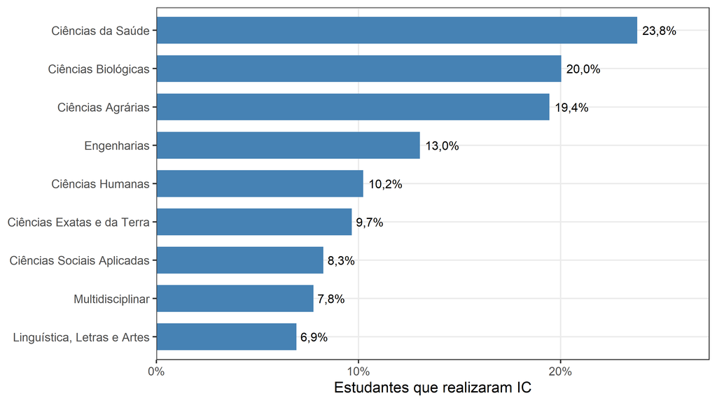

Figura 1: Proporção de estudantes que realizaram IC, por área do conhecimento

```r
tab_areas |>
  ggplot2::ggplot(ggplot2::aes(x = stats::reorder(area, fez_ic), y = fez_ic)) +
  ggplot2::geom_col(fill = "steelblue", width = 0.7) +
  ggplot2::geom_text(ggplot2::aes(label = pct(fez_ic)), hjust = -0.15, size = 3.4) +
  ggplot2::scale_y_continuous(labels = scales::percent,
                              expand = ggplot2::expansion(mult = c(0, 0.15))) +
  ggplot2::coord_flip() +
  ggplot2::labs(x = NULL, y = "Estudantes que realizaram IC") +
  TEMA
```

Ciências da Saúde forma estudantes com IC em proporção mais de três vezes maior que Linguística, Letras e Artes. A FFLCH, com 10,0%, fica próxima da média de sua área, mas bem abaixo da média da universidade (12,4%) — o estudo anterior, portanto, descreveu uma unidade situada na metade inferior da distribuição.

A composição social não acompanha o acesso. As áreas que mais formam iniciantes científicos não são as que recebem estudantes mais privilegiados: a mediana de renda per capita é praticamente a mesma em Ciências da Saúde e em Ciências Humanas. O que separa as duas é a proporção de estudantes noturnos e trabalhadores — 51,2% e 44,6% em Humanas, contra 19,0% e 13,8% na Saúde.

## 3.1 A dispersão dentro das áreas

Agregar em nove áreas esconde parte do fenômeno. A variação entre unidades da mesma área é, em vários casos, maior que a variação entre áreas.

**código**

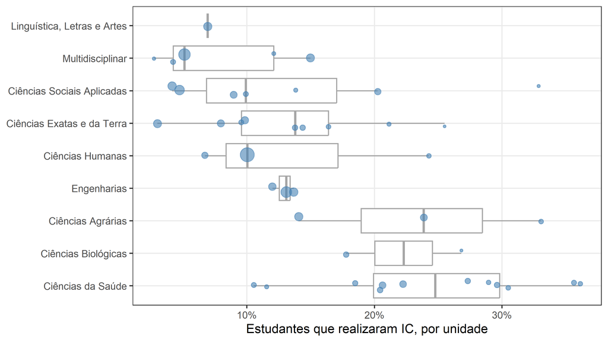

Figura 2: Proporção que realizou IC em cada unidade, agrupada por área (unidades com 500 ingressantes ou mais)

```r
tab_unidades <- usp |>
  dplyr::group_by(area, unidade) |>
  dplyr::summarise(n = dplyr::n(), fez_ic = mean(IC), .groups = "drop") |>
  dplyr::filter(n >= MIN_INGRESSANTES)

tab_unidades |>
  ggplot2::ggplot(ggplot2::aes(x = area, y = fez_ic)) +
  ggplot2::geom_boxplot(outlier.shape = NA, colour = "grey65") +
  ggplot2::geom_jitter(ggplot2::aes(size = n), width = 0.15, alpha = 0.6,
                       colour = "steelblue") +
  ggplot2::scale_y_continuous(labels = scales::percent) +
  ggplot2::scale_size_continuous(range = c(1, 6), guide = "none") +
  ggplot2::coord_flip() +
  ggplot2::labs(x = NULL, y = "Estudantes que realizaram IC, por unidade") +
  TEMA
```

**código**

```r
ext <- tab_unidades |> dplyr::arrange(dplyr::desc(fez_ic))
rbind(utils::head(ext, 5), utils::tail(ext, 5)) |>
  dplyr::transmute(Unidade = unidade, `Área` = area, N = num(n),
                   `% que fez IC` = pct(fez_ic)) |>
  knitr::kable(align = "llrr")
```

Tabela 3: As cinco unidades com maior e menor acesso à IC

| Unidade | Área | N | % que fez IC |
| --- | --- | --- | --- |
| Escola de Enfermagem | Ciências da Saúde | 1.071 | 36,1% |
| Faculdade de Odontologia de Bauru | Ciências da Saúde | 1.439 | 35,6% |
| Faculdade de Medicina Veterinária e Zootecnia | Ciências Agrárias | 1.098 | 33,1% |
| Instituto de Arquitetura e Urbanismo de São Carlos | Ciências Sociais Aplicadas | 575 | 32,9% |
| Faculdade de Ciências Farmacêuticas de Ribeirão Preto | Ciências da Saúde | 1.092 | 30,5% |
| Faculdade de Economia, Administração, Contabilidade e Atuária | Ciências Sociais Aplicadas | 8.341 | 4,7% |
| Pró-reitoria de Graduação | Multidisciplinar | 1.419 | 4,2% |
| Faculdade de Direito | Ciências Sociais Aplicadas | 6.180 | 4,1% |
| Instituto de Matemática e Estatística | Ciências Exatas e da Terra | 5.299 | 3,0% |
| Interunidades de Licenciatura IFSC/IQSC/ICMC | Multidisciplinar | 588 | 2,7% |

## 3.2 Descendo ao curso

A unidade ainda agrega demais. A Escola Politécnica oferta dezenas de engenharias; a FFLCH oferta Letras e Filosofia lado a lado. O curso é a unidade em que o estudante de fato vive, e é nele que a desigualdade de oferta aparece em toda a sua extensão.

**código**

```r
MIN_CURSO <- 200

cursos <- usp |>
  dplyr::group_by(area, unidade, curso) |>
  dplyr::summarise(n = dplyr::n(), fez_ic = mean(IC), .groups = "drop") |>
  dplyr::filter(n >= MIN_CURSO) |>
  dplyr::arrange(dplyr::desc(fez_ic))

# O mesmo nome de curso existe em unidades diferentes -- Odontologia em três
# faculdades, por exemplo. O rótulo carrega a unidade para não confundi-los.
cursos <- cursos |>
  dplyr::group_by(curso) |>
  dplyr::mutate(rotulo = if (dplyr::n() > 1)
                  paste0(curso, " — ", campus_unidade(unidade)) else curso) |>
  dplyr::ungroup()

rbind(utils::head(cursos, 10), utils::tail(cursos, 10)) |>
  dplyr::transmute(Curso = rotulo, `Área` = abreviar_area(area),
                   N = num(n), `% que fez IC` = pct(fez_ic)) |>
  knitr::kable(align = "llrr")
```

Tabela 4: Os dez cursos com maior e menor proporção de estudantes que realizaram IC

| Curso | Área | N | % que fez IC |
| --- | --- | --- | --- |
| Odontologia — Bauru | C. da Saúde | 656 | 45,4% |
| Enfermagem — São Paulo | C. da Saúde | 1.071 | 36,1% |
| Farmácia - Bioquímica — Ribeirão Preto | C. da Saúde | 836 | 34,8% |
| Medicina Veterinária — Pirassununga | C. Agrárias | 838 | 33,2% |
| Medicina Veterinária — São Paulo | C. Agrárias | 1.098 | 33,1% |
| Arquitetura e Urbanismo — São Carlos | C. Sociais Aplicadas | 575 | 32,9% |
| Fonoaudiologia — Bauru | C. da Saúde | 478 | 32,8% |
| Ciências Biológicas — Ribeirão Preto | Multidisciplinar | 651 | 32,7% |
| Fonoaudiologia — São Paulo | C. da Saúde | 344 | 31,4% |
| Bacharelado e Licenciatura em Enfermagem | C. da Saúde | 672 | 31,0% |
| Bacharelado em Ciências Atuariais | C. Sociais Aplicadas | 698 | 3,3% |
| Bacharelado em Sistemas de Informação — São Paulo | C. Exatas e da Terra | 673 | 3,3% |
| Bacharelado em Administração — Piracicaba | C. Agrárias | 421 | 3,1% |
| Licenciatura em Ciências Exatas | Multidisciplinar | 588 | 2,7% |
| Bacharelado em Lazer e Turismo | Multidisciplinar | 1.586 | 2,5% |
| Marketing | Multidisciplinar | 1.610 | 2,4% |
| Bacharelado em Matemática Aplicada e Computacional | C. Exatas e da Terra | 878 | 1,9% |
| Licenciatura em Geociências e Educação Ambiental | C. Exatas e da Terra | 625 | 1,9% |
| Matemática Licenciatura | C. Exatas e da Terra | 2.138 | 0,9% |
| Licenciatura em Ciências | Multidisciplinar | 1.064 | 0,8% |

**código**

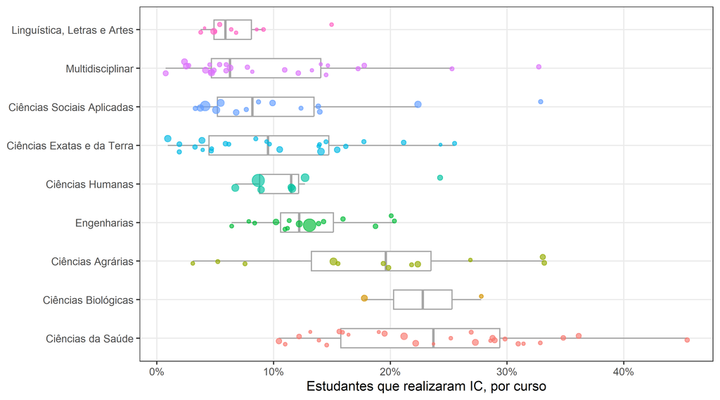

Figura 3: Proporção que realizou IC em cada curso, agrupada por área (cursos com 200 ingressantes ou mais)

```r
cursos |>
  ggplot2::ggplot(ggplot2::aes(x = area, y = fez_ic)) +
  ggplot2::geom_boxplot(outlier.shape = NA, colour = "grey65", width = 0.5) +
  ggplot2::geom_jitter(ggplot2::aes(size = n, colour = area), width = 0.18,
                       alpha = 0.65, show.legend = FALSE) +
  ggplot2::scale_y_continuous(labels = scales::percent) +
  ggplot2::scale_size_continuous(range = c(0.8, 5), guide = "none") +
  ggplot2::coord_flip() +
  ggplot2::labs(x = NULL, y = "Estudantes que realizaram IC, por curso") +
  TEMA
```

### 3.2.1 As licenciaturas

Um padrão organiza boa parte do fundo do ranking.

**código**

```r
# O nome do curso não identifica o vínculo: a maioria não traz "Bacharelado"
# nem "Licenciatura" no nome. Os campos de situação do painel marcam a ausência
# de vínculo com a frase "Não cursa/cursou ...", e não com um valor faltante.
tem_vinculo <- function(x, ausencia) !is.na(x) & x != ausencia

usp |>
  dplyr::mutate(
    bac = tem_vinculo(situ_bacharel,     "Não cursa/cursou bacharelado"),
    lic = tem_vinculo(situ_licenciatura, "Não cursa/cursou licenciatura"),
    tipo = dplyr::case_when(
      bac & lic  ~ "Bacharelado e licenciatura",
      bac & !lic ~ "Somente bacharelado",
      !bac & lic ~ "Somente licenciatura",
      TRUE       ~ "Sem vínculo registrado")) |>
  dplyr::group_by(tipo) |>
  dplyr::summarise(N = dplyr::n(), fez_ic = mean(IC), .groups = "drop") |>
  dplyr::arrange(dplyr::desc(fez_ic)) |>
  dplyr::transmute(`Vínculo` = tipo, N = num(N),
                   `% que fez IC` = pct(fez_ic)) |>
  knitr::kable(align = "lrr")
```

Tabela 5: Acesso à IC segundo o vínculo do estudante com bacharelado e licenciatura

| Vínculo | N | % que fez IC |
| --- | --- | --- |
| Bacharelado e licenciatura | 13.946 | 15,7% |
| Somente bacharelado | 82.791 | 13,0% |
| Sem vínculo registrado | 46.771 | 11,2% |
| Somente licenciatura | 9.221 | 7,0% |

Estudantes vinculados apenas à licenciatura realizam IC em proporção pouco acima da metade da dos vinculados apenas ao bacharelado. A leitura mais provável não é de desigualdade, mas de desenho: a licenciatura forma professores, e a iniciação científica não faz parte do que se espera dessa trajetória. Mas o efeito prático é que uma porta para a pós-graduação está estatisticamente mais fechada para quem entrou pela formação docente — e vale notar que essa é, na USP, a modalidade com maior concentração de estudantes noturnos e trabalhadores.

## 3.3 A estrutura institucional contra as características individuais

A amplitude entre unidades sugere que o lugar em que o estudante entra importa. Quanto? Uma forma direta de responder é comparar o poder explicativo de um modelo que só conhece a unidade do estudante com o de um modelo que só conhece suas características socioeconômicas.

**código**

```r
md_ind <- amostra_modelo(usp)

pseudo <- function(m, dados) {
  nulo <- stats::glm(IC ~ 1, data = dados, family = stats::binomial)
  1 - as.numeric(stats::logLik(m) / stats::logLik(nulo))
}

m_nada    <- stats::glm(IC ~ area,     data = usp, family = stats::binomial)
m_unidade <- stats::glm(IC ~ unidade,  data = usp, family = stats::binomial)
m_indiv   <- ajustar(md_ind, FORMULA_BASE)

data.frame(
  `O que o modelo conhece` = c(
    "Apenas a área do conhecimento (9 categorias)",
    "Apenas a unidade de ingresso (48 categorias)",
    "Apenas as características do estudante (o modelo do estudo anterior)"),
  `Pseudo-R²` = sprintf("%.3f", c(pseudo(m_nada, usp), pseudo(m_unidade, usp),
                                  pseudo(m_indiv, md_ind))),
  check.names = FALSE
) |>
  knitr::kable(align = "lr")
```

Tabela 6: Poder explicativo de cada bloco de informação, isoladamente

| O que o modelo conhece | Pseudo-R² |
| --- | --- |
| Apenas a área do conhecimento (9 categorias) | 0.034 |
| Apenas a unidade de ingresso (48 categorias) | 0.063 |
| Apenas as características do estudante (o modelo do estudo anterior) | 0.056 |

O resultado é desconfortável para a literatura de desigualdade de oportunidades educacionais, inclusive para o nosso estudo anterior. **Saber apenas em qual das 48 unidades o estudante entrou explica mais da variação individual em fazer IC do que saber sua renda, raça, escolaridade dos pais, idade, turno, vínculo com trabalho e forma de sustento, todos juntos.** A oferta desigual de oportunidades entre unidades é um fato estrutural que antecede — e supera — a seleção de quem as ocupa.

# 4 A especificação da FFLCH aplicada à USP

Mantemos a especificação do estudo anterior intacta. Se mudássemos o modelo junto com a amostra, não saberíamos qual das duas mudanças explica a diferença.

**código**

```r
md_fflch <- amostra_modelo(fflch)
md_usp   <- amostra_modelo(usp, com_area = TRUE)

m_fflch <- ajustar(md_fflch, FORMULA_BASE)
m_usp   <- ajustar(md_usp,   FORMULA_AREA)

ames <- rbind(
  cbind(modelo = "FFLCH", ame(m_fflch, md_fflch)),
  cbind(modelo = "USP",   ame(m_usp,   md_usp))
)

comparacao <- ames |>
  dplyr::filter(!grepl("^area", variavel)) |>
  dplyr::mutate(pp = sprintf("%+.2f", 100 * ame),
                termo = paste0(variavel, ": ", nivel)) |>
  dplyr::select(termo, modelo, pp) |>
  tidyr::pivot_wider(names_from = modelo, values_from = pp)

knitr::kable(comparacao, align = "lrr", col.names = c("Efeito", "FFLCH", "USP"))
```

Tabela 7: Efeitos marginais médios sobre a probabilidade de realizar IC, em pontos percentuais

| Efeito | FFLCH | USP |
| --- | --- | --- |
| ano: +1 desvio-padrão | -1.73 | -2.80 |
| idade: +1 desvio-padrão | -3.46 | -2.87 |
| sexo: M (vs F) | -0.12 | -3.13 |
| raca: PPI (vs Brancos) | -1.18 | -1.73 |
| educ_resp: EM completo (vs EF incompleto) | +0.39 | -0.28 |
| educ_resp: ES completo (vs EF incompleto) | +0.59 | -0.40 |
| sfmpct: +1 desvio-padrão | -1.20 | -0.77 |
| trabalho: Sim, em tempo integral (vs Não) | -2.35 | -3.73 |
| trabalho: Sim, em tempo parcial (vs Não) | +0.25 | -1.25 |
| sustento: Por conta própria (vs Suporte da família) | -2.89 | -3.28 |
| sustento: Com bolsa e apoio da família (vs Suporte da família) | +2.26 | +1.75 |
| sustento: Com trabalho e apoio da família (vs Suporte da família) | -2.64 | -2.23 |
| sustento: Outros (vs Suporte da família) | +1.54 | -0.36 |
| periodo: noturno (vs diurno) | -2.72 | -3.06 |
| class_carreira: +1 desvio-padrão | -1.21 | -1.89 |

**código**

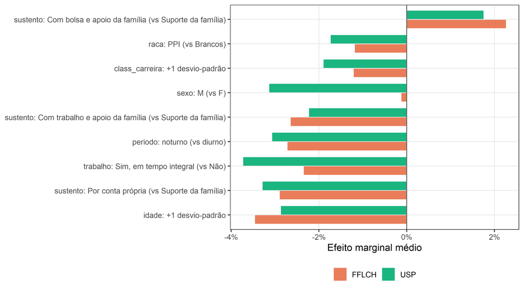

Figura 4: Os maiores efeitos marginais médios: FFLCH e USP lado a lado

```r
principais <- ames |>
  dplyr::filter(!grepl("^area|^ano", variavel)) |>
  dplyr::mutate(rotulo = paste0(variavel, ": ", nivel))

top <- principais |>
  dplyr::group_by(rotulo) |>
  dplyr::summarise(m = max(abs(ame)), .groups = "drop") |>
  dplyr::slice_max(m, n = 9) |>
  dplyr::pull(rotulo)

principais |>
  dplyr::filter(rotulo %in% top) |>
  ggplot2::ggplot(ggplot2::aes(x = stats::reorder(rotulo, ame), y = ame,
                               fill = modelo)) +
  ggplot2::geom_col(position = ggplot2::position_dodge(width = 0.75), width = 0.7) +
  ggplot2::geom_hline(yintercept = 0, colour = "grey40") +
  ggplot2::scale_y_continuous(labels = scales::percent) +
  ggplot2::scale_fill_manual(values = c("FFLCH" = "#e97d5a", "USP" = "#1bb57f")) +
  ggplot2::coord_flip() +
  ggplot2::labs(x = NULL, y = "Efeito marginal médio", fill = NULL) +
  TEMA
```

Três leituras.

**O mecanismo do trabalho se confirma, e se fortalece.** Trabalhar em tempo integral ao prestar o vestibular reduz a probabilidade de fazer IC em 3.73 pontos percentuais na USP, contra 2.35 na FFLCH. Pretender se sustentar por conta própria e estudar no período noturno seguem na mesma direção, também com efeitos maiores. O argumento central do estudo anterior não era um artefato da unidade analisada.

**As características de origem seguem fracas — e a escolaridade dos pais muda de sinal.** Renda per capita e raça continuam com efeitos pequenos. A escolaridade do responsável, que na FFLCH tinha sinal positivo e não significativo, na USP passa a negativa: filhos de pais com ensino superior fazem *menos* IC, não mais. É um resultado contraintuitivo que merece investigação própria, e que reforça a leitura de que, dentro de uma universidade seletiva, a origem opera de modo distinto do que opera no acesso a ela.

**O sexo, invisível na FFLCH, aparece na USP.** Na FFLCH o efeito de ser homem é -0.12 ponto percentual — indistinguível de zero. Na USP é -3.13 pontos. Como o modelo já inclui efeitos fixos de área, isso não é composição: não se trata de homens estarem concentrados em áreas com pouca IC. Dentro da mesma área, homens fazem menos IC que mulheres.

# 5 O mesmo modelo, área por área

Confirmar o mecanismo em agregado não garante que ele opere em toda parte. Se o trabalho for o obstáculo dominante em Humanas e irrelevante em Saúde, o achado anterior descreve um tipo de área, não a universidade.

**código**

```r
areas <- sort(unique(usp$area))

ajustes <- Filter(Negate(is.null), lapply(areas, function(a) {
  d <- amostra_modelo(dplyr::filter(usp, area == a))
  if (nrow(d) < 500) return(NULL)
  list(area = a, modelo = ajustar(d, FORMULA_BASE), dados = d)
}))

ames_area <- do.call(rbind, lapply(ajustes, function(x) {
  cbind(area = x$area, n = stats::nobs(x$modelo), ame(x$modelo, x$dados))
}))

DESTAQUES <- c(
  "trabalho|Sim, em tempo integral (vs Não)"          = "Trab. integral",
  "sustento|Por conta própria (vs Suporte da família)" = "Sust. próprio",
  "periodo|noturno (vs diurno)"                        = "Noturno",
  "sexo|M (vs F)"                                      = "Homem",
  "raca|PPI (vs Brancos)"                              = "PPI",
  "sfmpct|+1 desvio-padrão"                            = "Renda p/c",
  "educ_resp|ES completo (vs EF incompleto)"           = "Pais c/ ES"
)

destaques <- ames_area |>
  dplyr::mutate(chave = paste(variavel, nivel, sep = "|")) |>
  dplyr::filter(chave %in% names(DESTAQUES)) |>
  dplyr::mutate(efeito = factor(unname(DESTAQUES[chave]),
                                levels = unname(DESTAQUES)))

tab_het <- destaques |>
  dplyr::mutate(pp = sprintf("%+.1f", 100 * ame)) |>
  dplyr::select(area, n, efeito, pp) |>
  tidyr::pivot_wider(names_from = efeito, values_from = pp) |>
  # A ordem das colunas depois do pivot não é garantida: selecionamos pelos
  # nomes, em vez de confiar na posição e rotular por cima.
  dplyr::select(`Área` = area, N = n, dplyr::all_of(unname(DESTAQUES))) |>
  dplyr::mutate(`Área` = abreviar_area(`Área`), N = num(N))

knitr::kable(tab_het, align = "lrrrrrrrr")
```

Tabela 8: Efeitos marginais médios por área, em pontos percentuais

| Área | N | Trab. integral | Sust. próprio | Noturno | Homem | PPI | Renda p/c | Pais c/ ES |
| --- | --- | --- | --- | --- | --- | --- | --- | --- |
| C. da Saúde | 16.061 | -4.6 | -6.6 | -1.6 | -6.8 | -2.8 | -1.0 | -0.5 |
| C. Biológicas | 1.631 | -2.4 | -1.5 | -10.5 | -1.7 | -3.0 | -1.1 | -1.8 |
| C. Agrárias | 8.213 | -6.1 | -4.5 | +0.7 | -8.1 | -3.2 | -1.7 | -1.8 |
| Engenharias | 13.757 | -0.9 | -1.4 | -3.1 | -3.8 | -2.0 | -0.4 | -2.4 |
| C. Humanas | 19.430 | -2.6 | -3.0 | -3.4 | -0.1 | -1.2 | -1.2 | +0.6 |
| C. Exatas e da Terra | 14.256 | -3.8 | -3.2 | -4.7 | -2.5 | -1.7 | -0.4 | +1.7 |
| C. Sociais Aplicadas | 17.791 | -2.0 | -1.4 | -2.9 | -3.1 | -0.3 | -0.6 | -0.5 |
| Multidisciplinar | 16.061 | -4.1 | -1.8 | -2.2 | -0.6 | -1.6 | +0.1 | -0.6 |
| Letras e Artes | 4.130 | +0.2 | -2.8 | -3.4 | -0.6 | -0.1 | +0.0 | -1.9 |

**código**

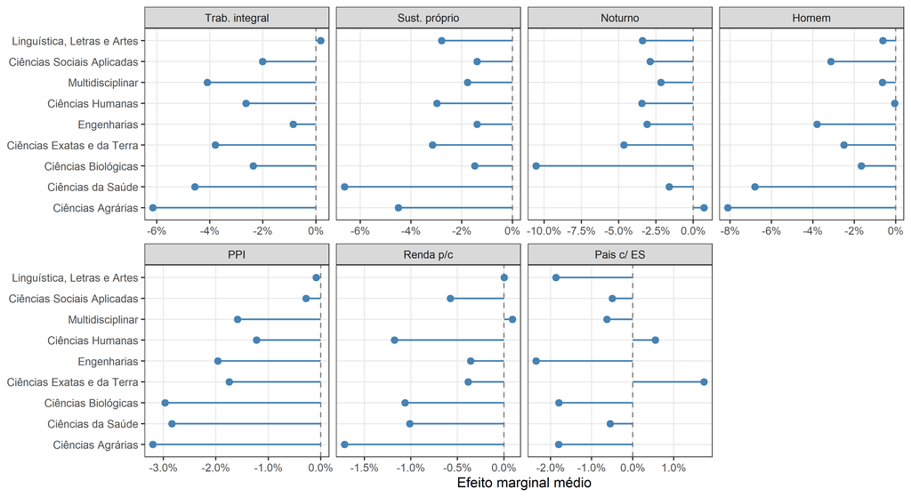

Figura 5: O mesmo efeito, área por área

```r
destaques |>
  ggplot2::ggplot(ggplot2::aes(x = stats::reorder(area, ame), y = ame)) +
  ggplot2::geom_hline(yintercept = 0, colour = "grey50", linetype = "dashed") +
  ggplot2::geom_segment(ggplot2::aes(xend = area, y = 0, yend = ame),
                        colour = "steelblue", linewidth = 0.7) +
  ggplot2::geom_point(size = 2.4, colour = "steelblue") +
  ggplot2::facet_wrap(~ efeito, ncol = 4, scales = "free_x") +
  ggplot2::scale_y_continuous(labels = scales::percent) +
  ggplot2::coord_flip() +
  ggplot2::labs(x = NULL, y = "Efeito marginal médio") +
  TEMA
```

A tabela responde à pergunta, e a resposta tem duas partes.

**código**

```r
maiores <- ames_area |>
  dplyr::filter(variavel != "ano", !grepl("^Outros", nivel)) |>
  dplyr::group_by(area) |>
  dplyr::slice_max(abs(ame), n = 1) |>
  dplyr::ungroup()

maiores |>
  dplyr::transmute(`Área` = area, N = num(n),
                   Fator = paste0(variavel, ": ", nivel),
                   `Efeito (pp)` = sprintf("%+.1f", 100 * ame)) |>
  knitr::kable(align = "lrlr")
```

Tabela 9: O fator de maior efeito em cada área

| Área | N | Fator | Efeito (pp) |
| --- | --- | --- | --- |
| Ciências da Saúde | 16.061 | sexo: M (vs F) | -6.8 |
| Ciências Biológicas | 1.631 | periodo: noturno (vs diurno) | -10.5 |
| Ciências Agrárias | 8.213 | sexo: M (vs F) | -8.1 |
| Engenharias | 13.757 | sexo: M (vs F) | -3.8 |
| Ciências Humanas | 19.430 | periodo: noturno (vs diurno) | -3.4 |
| Ciências Exatas e da Terra | 14.256 | periodo: noturno (vs diurno) | -4.7 |
| Ciências Sociais Aplicadas | 17.791 | sexo: M (vs F) | -3.1 |
| Multidisciplinar | 16.061 | trabalho: Sim, em tempo integral (vs Não) | -4.1 |
| Linguística, Letras e Artes | 4.130 | periodo: noturno (vs diurno) | -3.4 |

**código**

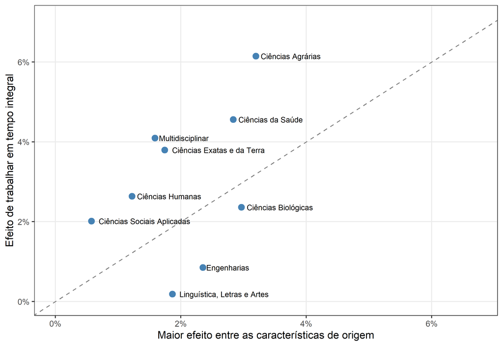

Figura 6: Trabalho contra origem social: acima da diagonal, o trabalho pesa mais

```r
largo <- destaques |>
  dplyr::select(area, efeito, ame) |>
  tidyr::pivot_wider(names_from = efeito, values_from = ame)

conf <- largo |>
  dplyr::mutate(trabalho = abs(`Trab. integral`),
                origem = pmax(abs(PPI), abs(`Renda p/c`),
                              abs(`Pais c/ ES`)))

conf |>
  ggplot2::ggplot(ggplot2::aes(x = origem, y = trabalho, label = area)) +
  ggplot2::geom_abline(slope = 1, intercept = 0, linetype = "dashed",
                       colour = "grey50") +
  ggplot2::geom_point(size = 3, colour = "steelblue") +
  ggplot2::geom_text(hjust = -0.08, size = 3.1) +
  ggplot2::expand_limits(x = c(0, max(conf$origem) * 2.1),
                         y = c(0, max(conf$trabalho) * 1.15)) +
  ggplot2::scale_x_continuous(labels = scales::percent) +
  ggplot2::scale_y_continuous(labels = scales::percent) +
  ggplot2::labs(x = "Maior efeito entre as características de origem",
                y = "Efeito de trabalhar em tempo integral") +
  TEMA
```

**A primeira parte confirma o estudo anterior.** O trabalho supera a maior das características de origem em 6 das 9 áreas. A hierarquia que encontramos na FFLCH — o tempo importa mais que a origem — não é uma peculiaridade daquela unidade.

**A segunda parte o qualifica.** Trabalhar em tempo integral é o fator de maior efeito em apenas 1 das 9 áreas. Nas demais, quem carrega o mecanismo é o **período noturno** (4 áreas) ou o **sexo** (4 áreas).

O sexo é outra história. Em Ciências Agrárias, da Saúde e Engenharias, ser homem reduz a probabilidade de fazer IC entre três e oito pontos percentuais — efeito maior que o de qualquer característica de origem, e maior que o do próprio trabalho. Como os modelos são estimados dentro de cada área, não se trata de segregação horizontal entre carreiras. É algo que acontece dentro das mesmas unidades. Nosso desenho não permite distinguir entre as explicações possíveis — diferenças de desempenho acadêmico, de disponibilidade para atividades não remuneradas, de relação com os orientadores, ou de custo de oportunidade no mercado de trabalho para essas formações. Registramos o padrão e o deixamos como pergunta.

# 6 Considerações finais

Estendemos à USP inteira um modelo construído para uma de suas unidades, e as três respostas não são as que esperávamos.

A primeira é que a heterogeneidade institucional supera tudo o que estávamos medindo. A proporção de estudantes que fazem IC vai de 2,7% a 36,1% entre unidades, e a unidade de ingresso, sozinha, explica mais da variação individual do que o conjunto das características socioeconômicas. Um estudo de desigualdade de oportunidades educacionais que olhe apenas para os atributos dos indivíduos está medindo a menor das duas fontes de variação. A oferta de IC é desigual antes de qualquer seleção de quem a ocupa — e essa desigualdade é uma decisão institucional, não um resultado agregado de escolhas individuais.

Duas limitações herdadas do estudo anterior permanecem e pesam mais aqui. Não temos indicador de desempenho acadêmico, e a classificação na carreira no vestibular é um proxy pobre — especialmente ao comparar áreas cujos processos seletivos têm concorrências muito diferentes. E o sub-registro de bolsas fora do CNPq no sistema Atena não é uniforme entre áreas: se as unidades das ciências experimentais registram melhor suas bolsas FAPESP do que as de humanidades, parte da diferença que atribuímos à área é diferença de registro. Não temos como quantificar esse viés com os dados disponíveis, e ele é a primeira coisa que um estudo seguinte deveria enfrentar.

# Referências

BREEN, R.; JONSSON, J. O. Inequality of Opportunity in Comparative Perspective — Recent Research on Educational Attainment and Social Mobility. **Annual Review of Sociology**, v. 31, p. 223–243, 2005.

CANAAN, M. G.; NOGUEIRA, M. A. Bens em disputa no campo universitário: o efeito de fatores socioeconômicos e culturais no acesso à bolsa de iniciação científica. *In*: MASSI, L.; QUEIROZ, S. L. (org.). **Iniciação científica: aspectos históricos, organizacionais e formativos da atividade no ensino superior brasileiro**. São Paulo: UNESP, 2015. p. 61–89.

CARVALHAES, F.; RIBEIRO, C. A. C. Estratificação horizontal da educação superior no Brasil: desigualdades de classe, gênero e raça em um contexto de expansão educacional. **Tempo Social**, v. 31, n. 1, p. 195–233, 2019.

COMIN, A. A.; BARBOSA, R. Trabalhar para estudar: sobre a pertinência da noção de transição escola-trabalho no Brasil. **Novos Estudos CEBRAP**, v. 91, p. 75–95, 2011.

MANÇANO, T.; ALCANTARA, V. Quem faz Iniciação Científica? Um estudo sobre as desigualdades socioeconômicas no acesso à Iniciação Científica FFLCH-USP (2010–2022). Pacote de replicação disponível em: https://github.com/mancano-tales/Quem-faz-IC.

MASSI, L.; QUEIROZ, S. L. **Iniciação científica: aspectos históricos, organizacionais e formativos da atividade no ensino superior brasileiro**. São Paulo: Editora UNESP, 2015.

RIBEIRO, C. A. C.; CARVALHAES, F. Estratificação e mobilidade social no Brasil: uma revisão da literatura na sociologia de 2000 a 2018. p. 1–46, 2020.

SENKEVICS, A. *et al.* Decomposing Heterogeneity in Inequality of Educational Opportunities: Family Income and Academic Performance in Brazilian Higher Education. **Sociological Science**, v. 11, p. 854–885, 2024.

# Ambiente computacional

**código**